# Regresi Linear Sederhana

Langkah pertama yang dilakukan adalah mengatur working directory pada R, serta tempatkan data yang tersedia pada file ini.

```r
setwd("D:\\DS\\R\\[R] Regresi Linear Sederhana")
```

```r
#Input Data
salary_data <-read.csv("Salary_Data.csv", header = T)
head(salary_data)
```

```
##   YearsExperience Salary
## 1             1.1  39343
## 2             1.3  46205
## 3             1.5  37731
## 4             2.0  43525
## 5             2.2  39891
## 6             2.9  56642
```

```r
attach(salary_data)
```

## Eksplorasi Data

Langkah selanjutnya adalah melakukan eksplorasi terhadap dataset, sebagai berikut :

```r
#Melihat karakteristik data
str(salary_data)
```

```
## 'data.frame':    30 obs. of  2 variables:
##  $ YearsExperience: num  1.1 1.3 1.5 2 2.2 2.9 3 3.2 3.2 3.7 ...
##  $ Salary         : num  39343 46205 37731 43525 39891 ...
```

Terlihat bahwa terdiri dari 30 baris (observasi) dan 2 kolom (variabel).

```r
#Melihat statistika deskriptif pada data
summary(salary_data)
```

```
##  YearsExperience      Salary
##  Min.   : 1.100   Min.   : 37731
##  1st Qu.: 3.200   1st Qu.: 56721
##  Median : 4.700   Median : 65237
##  Mean   : 5.313   Mean   : 76003
##  3rd Qu.: 7.700   3rd Qu.:100545
##  Max.   :10.500   Max.   :122391
```

Terlihat bahwa maksimum Salary adalah 122391 ribu rupiah, dan minimum Salary adalah 37731 ribu rupiah. Terlihat juga bahwa maksimum Years Experience adalah 10,5 tahun dan minimum Years Experience adalah 1,1 tahun.

```r
#Melihat apakah ada missing value pada data
is.na(salary_data)
```

```
##       YearsExperience Salary
##  [1,]           FALSE  FALSE
##  [2,]           FALSE  FALSE
##  [3,]           FALSE  FALSE
##  [4,]           FALSE  FALSE
##  [5,]           FALSE  FALSE
##  [6,]           FALSE  FALSE
##  [7,]           FALSE  FALSE
##  [8,]           FALSE  FALSE
##  [9,]           FALSE  FALSE
## [10,]           FALSE  FALSE
## [11,]           FALSE  FALSE
## [12,]           FALSE  FALSE
## [13,]           FALSE  FALSE
## [14,]           FALSE  FALSE
```

[output cut: 16 more lines]

Terlihat bahwa tidak ada data yang kosong pada dataset.

Langkah selanjutnya adalah memilih variabel respon dan variabel prediktor. Variabel respon yang digunakan adalah Salary dan variabel prediktor yang digunakan adalah YearsExperience.

```r
#Memilih variabel respon
Y <- Salary
head(Y)
```

```
## [1] 39343 46205 37731 43525 39891 56642
```

```r
#Memilih variabel prediktor
X <- YearsExperience
head(X)
```

```
## [1] 1.1 1.3 1.5 2.0 2.2 2.9
```

Langkah selanjutnya adalah membuat plot data set, sebagai berikut :

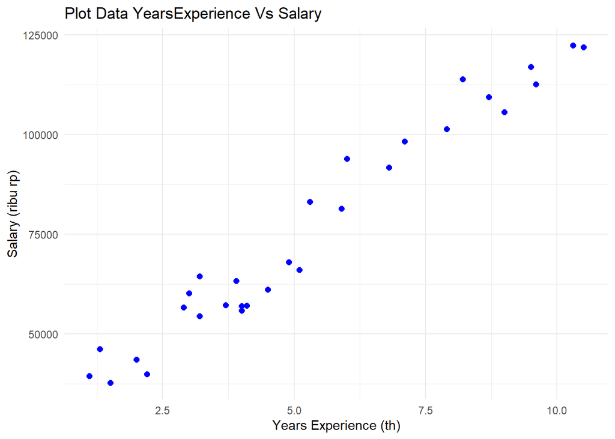

## Split Data

Langkah selanjutnya adalah membagi data ke dalam Training data dan Testing data, sebagai berikut :

```r
library(caTools)
set.seed(123)
split <- sample.split(salary_data$Salary, SplitRatio = 0.8)
salary_train <- subset(salary_data, split==TRUE)
salary_test <-subset(salary_data, split==FALSE)

X_train <- salary_train$YearsExperience
Y_train <- salary_train$Salary
X_test <- salary_test$YearsExperience
Y_test <- salary_test$Salary
```

## Model Regresi Linear Sederhana

Langkah selanjutnya adalah membuat model terhadap Training data, sebagai berikut :

```r
lm <- lm(Y_train~X_train, salary_train)
summary(lm)
```

```
##
## Call:
## lm(formula = Y_train ~ X_train, data = salary_train)
##
## Residuals:
##     Min      1Q  Median      3Q     Max
## -7810.8 -3698.7   747.8  3046.1  8162.0
##
## Coefficients:
##             Estimate Std. Error t value Pr(>|t|)
## (Intercept)  26995.6     2262.0   11.93 4.42e-11 ***
## X_train       9152.3      364.8   25.09  < 2e-16 ***
## ---
## Signif. codes:  0 '***' 0.001 '**' 0.01 '*' 0.05 '.' 0.1 ' ' 1
##
## Residual standard error: 5260 on 22 degrees of freedom
## Multiple R-squared:  0.9662, Adjusted R-squared:  0.9647
## F-statistic: 629.6 on 1 and 22 DF,  p-value: < 2.2e-16
```

Sehingga diperoleh model regresi terhadap Training data adalah : $Y=26996+9152X$ Interpretasi model : - Jika YearsExperience adalah 0 tahun maka Salary bernilai 26996 ribu rupiah - Jika YearsExperience meningkat 1 tahun maka Salary akan meningkat 9152 ribu rupiah

Langkah selanjutnya adalah melakukan prediksi pada Testing data dengan menggunakan Training model. Sehingga diperoleh nilai Y prediksi sebagai berikut :

```r
library(caret)
X_test<-data.frame(X_train = X_test)
Y_pred <- predict(lm, data.frame(X_test))
Y_pred
```

```
##         1         2         3         4         5         6
##  47130.67  56282.97  62689.58  71841.88  81909.41 102044.47
```

Nilai Y prediksi dapat dibandingkan dengan nilai Y aktual sebagai berikut :

```r
Y_test
```

```
## [1]  39891  54445  63218  67938  93940 113812
```

## Uji Asumsi

Langkah selanjutnya adalah melakukan uji asumsi, sebagai berikut :

```r
#Uji Asumsi Kenormalan
residual <- resid(lm)
shapiro.test(residual)
```

```
##
##  Shapiro-Wilk normality test
##
## data:  residual
## W = 0.93981, p-value = 0.1616
```

Hipotesis :

$H_0$ : Residual menyebar normal

$H_1$ : Residual tidak menyebar normal

Dapat dilihat nilai p-value = 0,1616 > alpha = 0,05 hal ini berati Terima $H_0$, sehingga residual menyebar normal.

```r
#Uji Autokorelasi
library(lmtest)
dwtest(lm, data=salary_train)
```

```
##
##  Durbin-Watson test
##
## data:  lm
## DW = 1.2904, p-value = 0.01941
## alternative hypothesis: true autocorrelation is greater than 0
```

Hipotesis :

$H_0$ : Tidak ada autokorelasi

$H_1$ : Ada autokorelasi

```r
#Uji Heteroskedastisitas
bptest(lm, data = salary_train)
```

```
##
##  studentized Breusch-Pagan test
##
## data:  lm
## BP = 3.6241, df = 1, p-value = 0.05695
```

Hipotesis :

$H_0$ : Tidak ada heteroskedastisitas

$H_1$ : Ada heteroskedastisitas

Dapat dilihat nilai p-value = 0,05695 > alpha = 0,05 hal ini berati Terima $H_0$, sehingga tidak ada heteroskedastisitas.

## Evaluasi Model

Langkah selanjutnya adalah melakukan evaluasi terhadap model yang telah dibuat, dengan melihat nilai MSE dan $R^2$ sebagai berikut :

```r
#Evaluasi Model
library(Metrics)
mse(Y_test, Y_pred)
```

```
## [1] 59086716
```

```r
summary(lm)$r.squared
```

```
## [1] 0.9662358
```

Sehingga diperoleh nilai $R^2$ adalah 0,966 hal ini berati sebesar 96,6% model dapat menjelaskan variabel YearsExperience dan Salary dan sebesar 3,4% dijelaskan oleh variabel - variabel lain diluar model. Hal ini berati model sudah cukup baik untuk digunakan.

Langkah selanjutnya adalah membuat plot data beserta garis linearnya, sebagai berikut :

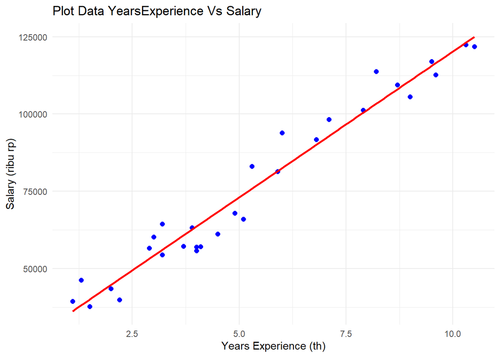